# WTA_Project_Notebook

Samaher

2024-04-19

## Data Description

`tourney_id`: a unique identifier for each tournament.

`tourney_name`: the name of the tournament

`surface`: Hard, Clay, or Grass

`draw_size`: number of players in the draw, often rounded up to the nearest power of 2. (For instance, a tournament with 28 players may be shown as 32.)

`tourney_level`: ‘G’ = Grand Slams ‘F’ = WTA finals ‘PM’ = Premier Mandatory ‘P’ = Premier ‘I’ = International ‘D’ is used for Federation/Fed/Billie Jean King Cup, and also for Wightman Cup and Bonne Bell Cup.

`tourney_date`: eight digits, YYYYMMDD, usually the Monday of the tournament week.

`match_num`: a match-specific identifier. Often starting from 1, sometimes counting down from 300, and sometimes arbitrary.

`winner_id`: the player_id used in this repo for the winner of the match

`winner_seed`

`winner_entry`: ‘WC’ = wild card ‘Q’ = qualifier ‘LL’ = lucky loser ‘ALT’ = Alternate ‘SE’ = Special Exemption ‘SR’ = Special Exempt

`winner_name`

`winner_hand`: R = right, L = left, U = unknown. For ambidextrous players, this is their serving hand.

`winner_ht`: height in centimeters, where available

`winner_ioc`: three-character country code

`winner_age`: age, in years, as of the tourney_date

`loser_id`

`loser_seed`

`loser_entry`

`loser_name`

`loser_hand`

`loser_ht`

`loser_ioc`

`loser_age`

`score`

`best_of`:‘3’, indicating the the number of sets for this match

`round`

`minutes`: match length, where available

`w_ace`: winner’s number of aces

`w_df`: winner’s number of doubles faults

`w_svpt`: winner’s number of serve points

`w_1stIn`: winner’s number of first serves made

`w_1stWon`: winner’s number of first-serve points won

`w_2ndWon`: winner’s number of second-serve points won

`w_SvGms`: winner’s number of serve games

`w_bpSaved`: winner’s number of break points saved

`w_bpFaced`: winner’s number of break points faced

`l_ace`

`l_df`

`l_svpt`

`l_1stIn`

`l_1stWon`

`l_2ndWon`

`l_SvGms`

`l_bpSaved`

`l_bpFaced`

`winner_rank`: winner’s WTA rank, as of the tourney_date, or the most recent ranking date before the tourney_date

`winner_rank_points`: number of ranking points, where available

`loser_rank`

`loser_rank_points`

## Data Preprocessing

```r
data <- read.csv("/Users/samaherbrahem/Documents/MSc DSE/Trimester 2/Statistical Learning/Individual Project/WTA/DSE_Statistical_Learning_Project/wta_matches_2023.csv")

data_backup <- data
```

1. Removing incomplete games (due to injury, walkover, etc)

```r
# Remove rows where score column contains "RET" or "W/O"
data <- subset(data, !(grepl("RET", score) | grepl("W/O", score)))
```

2. Splitting the score column set by set.

```r
# Split the score column into individual sets
sets <- strsplit(data$score, " ")

# Initialize vectors to store set scores
w_set1 <- numeric(length(sets))
l_set1 <- numeric(length(sets))
w_set2 <- numeric(length(sets))
l_set2 <- numeric(length(sets))
w_set3 <- numeric(length(sets))
l_set3 <- numeric(length(sets))

# Loop through each set and extract scores
for (i in seq_along(sets)) {
  scores <- gsub("\\(.*?\\)", "", sets[[i]])  # Remove numbers within parentheses
  scores <- unlist(strsplit(scores, "-"))
  w_set1[i] <- as.numeric(scores[1])
  l_set1[i] <- as.numeric(scores[2])
  if (length(scores) > 2) {
    w_set2[i] <- as.numeric(scores[3])
    l_set2[i] <- as.numeric(scores[4])
    if (length(scores) > 4) {
      w_set3[i] <- as.numeric(scores[5])
      l_set3[i] <- as.numeric(scores[6])
    }
  }
}

# Create new dataframe with set scores
set_scores <- data.frame(
  w_set1 = w_set1,
  l_set1 = l_set1,
  w_set2 = w_set2,
  l_set2 = l_set2,
  w_set3 = w_set3,
  l_set3 = l_set3
)

# Combine the new dataframe with the original dataset
data <- cbind(data, set_scores)

# Remove sets and set_scores since they're no longer needed
remove(sets, set_scores)
```

3. Encoding categorical variables

I want to highlight the fact that match is played in Grand Slam or not. We can get this info from `tourney_level`

```r
data$grand_slam <- 0
data$grand_slam[data$tourney_level == 'G'] <- 1
```

I want to highlight the fact that a match is in final rounds (Quarter final, Semi final, or Final) as opposed to preliminary rounds. We can get this info from `round`

```r
# Initialize "final_rounds" column with zeros
data$final_rounds <- 0

# Set the value to 1 for "QF", "SF", and "F"
data$final_rounds[data$round %in% c("QF", "SF", "F")] <- 1
```

Now I will reorder columns just for organizational reasons.

```r
library(dplyr)
```

```r
# Reordering columns
data <- data %>%
  select(X, tourney_id, tourney_name, surface, draw_size, tourney_level, grand_slam, tourney_date, match_num,
         winner_id, winner_seed, winner_entry, winner_name, winner_hand, winner_ht, winner_ioc,
         winner_age, loser_id, loser_seed, loser_entry, loser_name, loser_hand, loser_ht, loser_ioc,
         loser_age, score, w_set1, l_set1, w_set2, l_set2, w_set3, l_set3, best_of, round, final_rounds, everything())
```

4. Removing unnecessary columns

```r
data <- data[, !colnames(data) %in% c("X", "tourney_id", "draw_size", "match_num", "tourney_date", "winner_seed", "winner_id", "winner_entry", "loser_seed", "loser_entry", "best_of","tourney_level","loser_id","score","round")]
```

5. Checking for null values and removing them

```r
# Check the number of null values in each column
null_counts <- colSums(is.na(data))

# Print the result
print(null_counts)
```

```
##       tourney_name            surface         grand_slam        winner_name
##                  0                  0                  0                  0
##        winner_hand          winner_ht         winner_ioc         winner_age
##                  0                571                  0                  5
##         loser_name         loser_hand           loser_ht          loser_ioc
##                  0                  0                765                  0
##          loser_age             w_set1             l_set1             w_set2
##                  3                  0                  0                  0
##             l_set2             w_set3             l_set3       final_rounds
##                  0                  0                  0                  0
##            minutes              w_ace               w_df             w_svpt
##                259                202                202                202
##            w_1stIn           w_1stWon           w_2ndWon            w_SvGms
##                202                202                202                202
##          w_bpSaved          w_bpFaced              l_ace               l_df
##                202                202                202                202
##             l_svpt            l_1stIn           l_1stWon           l_2ndWon
##                202                202                202                202
##            l_SvGms          l_bpSaved          l_bpFaced        winner_rank
##                202                202                202                 24
## winner_rank_points         loser_rank  loser_rank_points
##                 24                 56                 56
```

```r
# Remove rows with NA values
data <- data[complete.cases(data), ]
```

6.creating a balanced dataset

A. Winners’ Point of view

```r
winner_pov <- data
```

```r
# Identify columns containing "w_" or "winner_"
winner_cols <- grep("w_", names(winner_pov))
winner_cols <- c(winner_cols, grep("winner_", names(winner_pov)))

# Replace "w_" with "p_" and "winner_" with "player_"
names(winner_pov)[winner_cols] <- gsub("w_", "p_", names(winner_pov)[winner_cols])
names(winner_pov)[winner_cols] <- gsub("winner_", "player_", names(winner_pov)[winner_cols])

# Identify columns containing "l_" or "loser_"
loser_cols <- grep("l_", names(winner_pov))
loser_cols <- c(loser_cols, grep("loser_", names(winner_pov))) # Columns with "loser_"

# Replace "l_" with "o_" and "loser_" with "opponent_"
names(winner_pov)[loser_cols] <- gsub("l_", "o_", names(winner_pov)[loser_cols])
names(winner_pov)[loser_cols] <- gsub("loser_", "opponent_", names(winner_pov)[loser_cols])

names(winner_pov)[names(winner_pov) == "finao_rounds"] <- "final_rounds"
```

now let’s add the response variable `win`

```r
winner_pov <- cbind(win = 1, winner_pov)
```

B. Losers’ Point of view

```r
loser_pov <- data
```

```r
# Identify columns containing "w_" or "winner_"
opponent_cols <- grep("w_", names(loser_pov))
opponent_cols <- c(opponent_cols, grep("winner_", names(loser_pov)))

# Replace "w_" with "o_" and "winner_" with "opponent_"
names(loser_pov)[opponent_cols] <- gsub("w_", "o_", names(loser_pov)[opponent_cols])
names(loser_pov)[opponent_cols] <- gsub("winner_", "opponent_", names(loser_pov)[opponent_cols])

# Identify columns containing "l_" or "loser_"
player_cols <- grep("l_", names(loser_pov))
player_cols <- c(player_cols, grep("loser_", names(loser_pov)))

# Replace "l_" with "p_" and "loser_" with "player_"
names(loser_pov)[player_cols] <- gsub("l_", "p_", names(loser_pov)[player_cols])
names(loser_pov)[player_cols] <- gsub("loser_", "player_", names(loser_pov)[player_cols])

# Rename the "finap_rounds" column to "final_rounds"
names(loser_pov)[names(loser_pov) == "finap_rounds"] <- "final_rounds"
```

now let’s add the response variable `win`

```r
loser_pov <- cbind(win = 0, loser_pov)
```

Reordering again for organizational reasons

```r
# Reorder columns of loser_pov to match winner_pov
loser_pov <- loser_pov[, names(winner_pov)]
```

Now, let’s merge both povs into 1 balanced data frame.

```r
# Add a variable to indicate the source (winner or loser)
winner_pov$source <- "winner"
loser_pov$source <- "loser"

# Merge the data frames
merged_data <- rbind(winner_pov, loser_pov)

# Randomly shuffle the merged data frame
set.seed(123) # Set seed for reproducibility
merged_data <- merged_data[sample(nrow(merged_data)), ]

# Select the first 50% of the observations
n_obs <- nrow(merged_data)
n_selected <- n_obs / 2
selected_data <- merged_data[1:n_selected, ]

# Remove the source variable
selected_data$source <- NULL
```

```r
# Compute the percentage of observations where win = 1 in the selected data
percentage_win_1 <- (sum(selected_data$win == 1) / nrow(selected_data)) * 100

percentage_win_1
```

```
## [1] 49.61089
```

```r
# Compute the percentage of observations where win = 0 in the selected data
percentage_win_0 <- (sum(selected_data$win == 0) / nrow(selected_data)) * 100

percentage_win_0
```

```
## [1] 50.38911
```

Renaming the data and removing unnecessary dataframes

```r
data <- selected_data

remove(winner_pov, loser_pov, merged_data, selected_data)
```

7. Limiting the data only to top 100 players for consistency reasons

```r
data <- data[data$player_rank <= 100 & data$opponent_rank <= 100, ]
numeric_data <- data[, sapply(data, is.numeric) & !names(data) %in% c("win", "GS", "final_rounds")]
```

8. Scaling Numerical Variables

```r
# Select only numeric columns except for "win", "GS", and "final_rounds"
numeric_data <- data[, sapply(data, is.numeric) & !names(data) %in% c("win", "final_rounds","grand_slam")]

# Scale the numeric columns
scaled_numeric_data <- scale(numeric_data)

# Combine the scaled numeric columns with the non-numeric columns
scaled_data <- cbind(data[, !sapply(data, is.numeric) | names(data) %in% c("win", "final_rounds","grand_slam")], scaled_numeric_data)

remove(scaled_numeric_data, numeric_data)
```

## Data Understanding

1. variables distribution

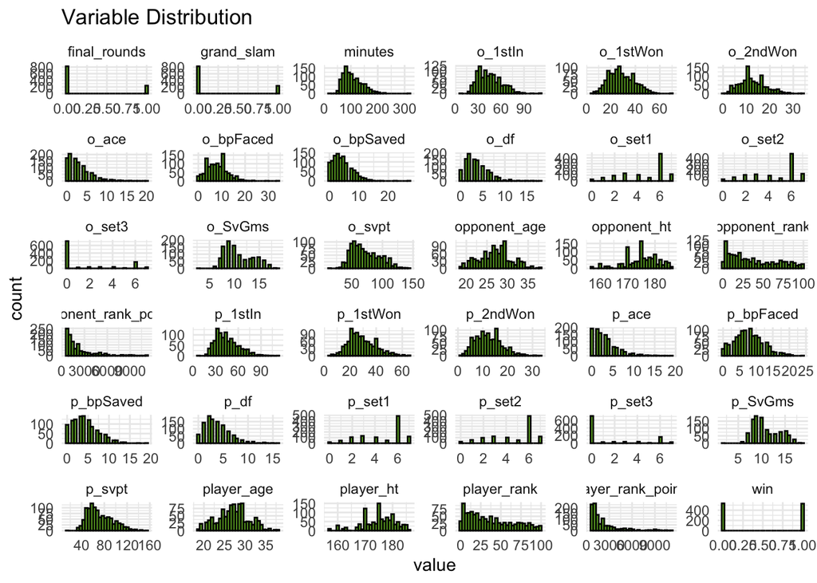

```r
library(ggplot2)

# Select only numerical variables
numerical_vars <- sapply(data, is.numeric)
data_subset <- data[, numerical_vars]

# Gather the data
data_long <- tidyr::gather(data_subset)

# Plot the histogram
ggplot(data_long, aes(x = value)) +
  geom_histogram(color = "black", fill = "#7bc133", bins = 30) +
  labs(title = "Variable Distribution") +
  facet_wrap(~ key, scales = "free") +
  theme_minimal()
```

```r
remove(numerical_vars, data_subset,data_long)
```

2. Checking outliers

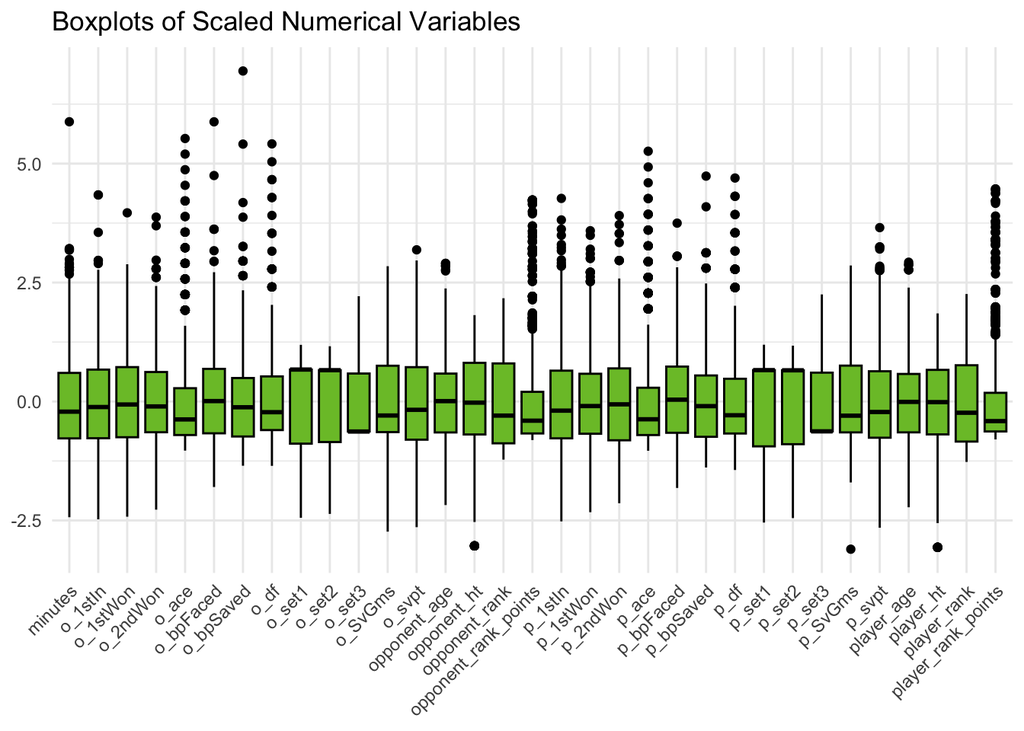

```r
library(ggplot2)

# Select only numerical variables excluding 'win', 'GS', and 'final_rounds'
numerical_vars <- sapply(scaled_data, is.numeric)
data_numeric <- scaled_data[, numerical_vars]
data_numeric <- data_numeric[, !(names(data_numeric) %in% c("win", "grand_slam", "final_rounds"))]

# Convert data to long format
data_long <- tidyr::gather(data_numeric, key = "variable", value = "value")

# Create boxplot using ggplot2
ggplot(data_long, aes(x = variable, y = value)) +
  geom_boxplot(fill = "#7bc133", color = "black") +
  labs(x = NULL, y = NULL, title = "Boxplots of Scaled Numerical Variables") +
  theme_minimal() +
  theme(axis.text.x = element_text(angle = 45, hjust = 1))
```

```r
remove(data_long, numerical_vars,data_numeric)
```

As you can see, I found some outliers in the data. But after looking at each variable separately and considering what I know about the game, I realized that most of these outliers were actually valid data points, not mistakes. So, I decided to keep them because they provide valuable insights into the full picture. Nevertheles, I corrected the ones I spotted, like this example where in the data set we have the length of the match between Ons Jabeur and Camila Osorio was 316 minutes but when I checked in the WTA it was 122 minutes only.

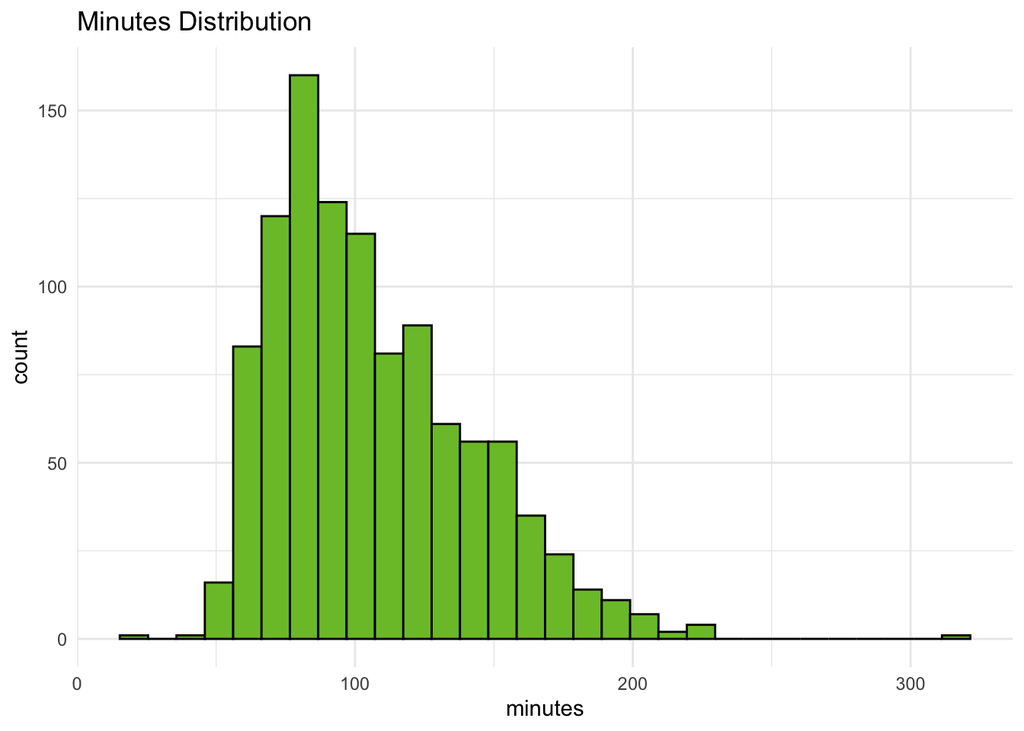

```r
library(ggplot2)

# Plot histogram of minutes distribution
ggplot(data, aes(x = minutes)) +
  geom_histogram(color = "black", fill = "#7bc133", bins = 30) +
  labs(title = "Minutes Distribution") +
  theme_minimal()
```

```r
# Identify the outlier
outlier <- data[which.max(data$minutes), c("player_name", "opponent_name", "minutes")]
outlier
```

```
##         player_name opponent_name minutes
## 19871 Camila Osorio    Ons Jabeur     316
```

```r
# After checking the correct value in WTA website, let's correct the minutes value in this match
data[data$player_name == "Camila Osorio" & data$opponent_name == "Ons Jabeur", "minutes"] <- 122

remove(outlier)
```

In this example however, the outlier identified in opponent/player hieght is a correct value. She’s the american player Lauren Davis with only 1.57 m as height.

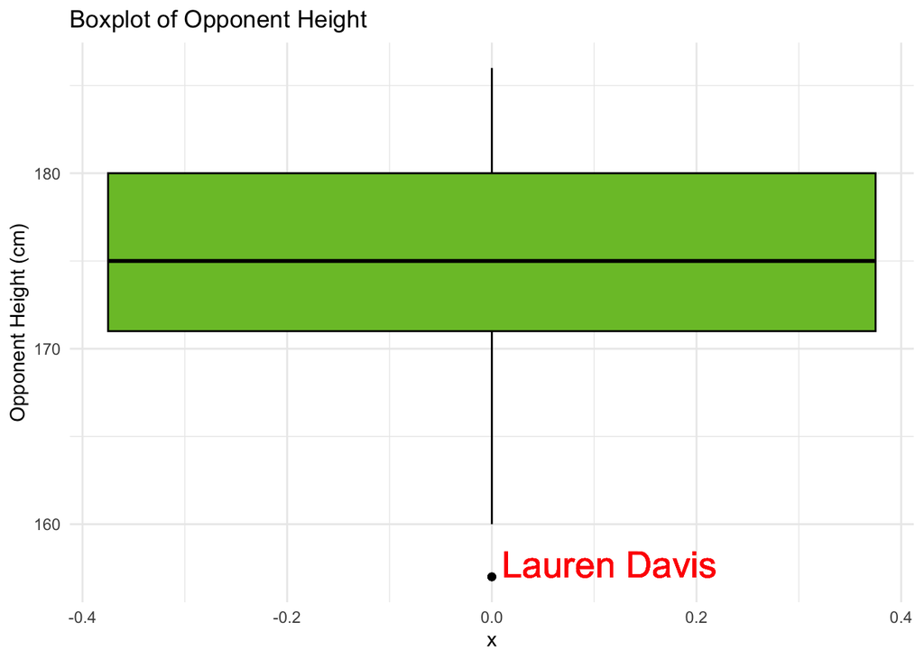

```r
# Boxplot of opponent_ht with annotations for outlier names
ggplot(data, aes(y = opponent_ht)) +
  geom_boxplot(fill = "#7bc133", color = "black") +
  labs(y = "Opponent Height (cm)", title = "Boxplot of Opponent Height") +
  theme_minimal() +
  geom_text(aes(label = ifelse(opponent_ht %in% boxplot.stats(data$opponent_ht)$out, opponent_name, ""),
                x = 0.01), hjust = 0, vjust = 0, color = "red", size = 7)
```

## Unsupervised Learning

```r
library(dplyr)
library(cluster)

# Combine player and opponent statistics
combined_data <- bind_rows(
  select(data, player_name, p_ace, p_df, p_svpt, p_1stWon, p_2ndWon, p_SvGms, p_bpSaved, p_bpFaced),
  select(data, opponent_name = player_name, p_ace = o_ace, p_df = o_df, p_svpt = o_svpt, p_1stWon = o_1stWon, p_2ndWon = o_2ndWon, p_SvGms = o_SvGms, p_bpSaved = o_bpSaved, p_bpFaced = o_bpFaced)
)

# Group by player_name and calculate the mean of each match statistic
unsup_data <- combined_data %>%
  group_by(player_name) %>%
  summarize(
    avg_p_ace = mean(p_ace),
    avg_p_df = mean(p_df),
    avg_p_svpt = mean(p_svpt),
    avg_p_1stWon = mean(p_1stWon),
    avg_p_2ndWon = mean(p_2ndWon),
    avg_p_SvGms = mean(p_SvGms),
    avg_p_bpSaved = mean(p_bpSaved),
    avg_p_bpFaced = mean(p_bpFaced)
  )

unsup_data <- na.omit(unsup_data)
remove(combined_data)

# Identify numeric columns
numeric_cols <- sapply(unsup_data, is.numeric)

# Scale only numeric columns
scaled_unsup_data <- unsup_data
scaled_unsup_data[numeric_cols] <- scale(unsup_data[numeric_cols])

# Convert to data frame
scaled_unsup_data <- as.data.frame(scaled_unsup_data)
```

I will add a dummy variable indicating if the player has been in the top 10 for that season or not.

```r
library(dplyr)

# Filter the players that were in the top 30 in the 2023 season
top_10 <- data %>%
  filter(player_rank <= 10) %>%
  distinct(player_name)

scaled_unsup_data <- scaled_unsup_data %>%
  mutate(top_10 = as.numeric(player_name %in% top_10$player_name))

remove(top_10)
```

Top 30

```r
library(dplyr)

# Filter the players that were in the top 30 in the 2023 season
top_30 <- data %>%
  filter(player_rank <= 30) %>%
  distinct(player_name)

scaled_unsup_data <- scaled_unsup_data %>%
  mutate(top_30 = as.numeric(player_name %in% top_30$player_name))

remove(top_30)
```

### TOP 30

#### 1. PCA

```r
## PCA TO TOP 30 PLAYERS ONLY

library(factoextra)
```

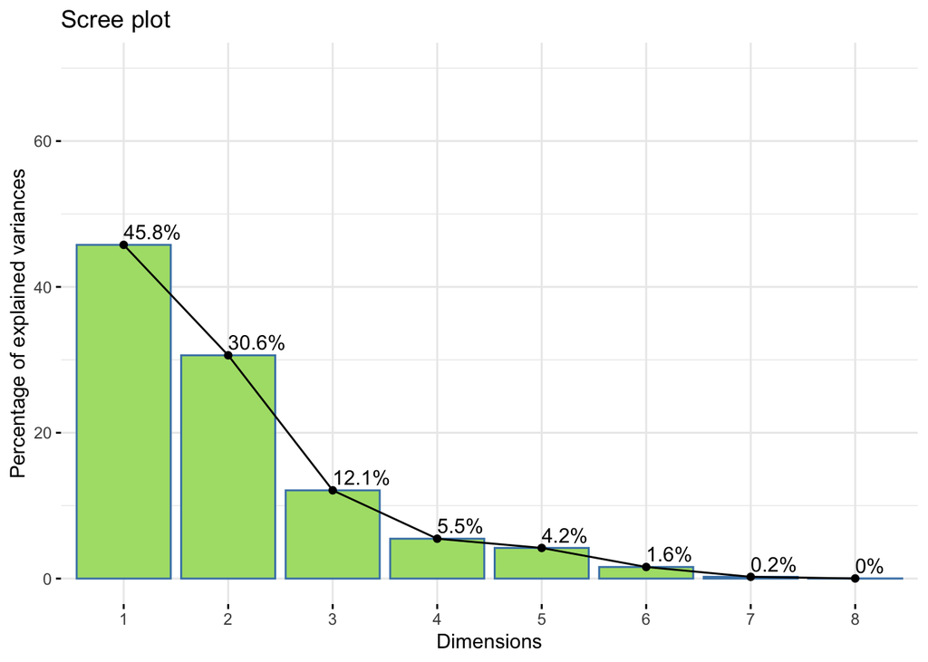

```r
# Filter out rows where top_10 is equal to 1
scaled_unsup_data_filtered_30 <- scaled_unsup_data[scaled_unsup_data$top_30 == 1, ]

# Exclude the player_name and top_30 columns
scaled_unsup_data_numeric_30 <- scaled_unsup_data_filtered_30[, -c(1, 10,11)]

# Perform PCA
pca_result_30 <- prcomp(scaled_unsup_data_numeric_30)

# Set row names of the PCA result to player names
rownames(pca_result_30$x) <- scaled_unsup_data_filtered_30$player_name

fviz_eig(pca_result_30, addlabels = TRUE, ylim=c(0,70), barfill="#acdf77")
```

```r
pca_result_30
```

```
## Standard deviations (1, .., p=8):
## [1] 1.52208349 1.24496473 0.78266333 0.52611318 0.46108490 0.28362758 0.10948414
## [8] 0.02852972
##
## Rotation (n x k) = (8 x 8):
##                       PC1         PC2         PC3           PC4        PC5
## avg_p_ace      0.02604829 -0.79187345  0.10664145  0.5341478232  0.2130759
## avg_p_df      -0.24888946 -0.32833327 -0.86734867 -0.2058129140 -0.1603564
## avg_p_svpt    -0.46888634 -0.03441660  0.15822879  0.0001103901 -0.1861440
## avg_p_1stWon  -0.27862817 -0.04723522  0.18960145  0.2966625557 -0.4961274
## avg_p_2ndWon  -0.32349224 -0.34297155  0.32906645 -0.6556163496  0.3802327
## avg_p_SvGms   -0.38042542 -0.07225294  0.20239799 -0.1083950365 -0.4673334
## avg_p_bpSaved -0.43061905  0.20218920 -0.05256603  0.2747349672  0.4430183
## avg_p_bpFaced -0.45286198  0.31302971 -0.15276112  0.2593393130  0.2980770
##                       PC6          PC7         PC8
## avg_p_ace     -0.17335656 -0.003076514  0.01040872
## avg_p_df       0.09715978 -0.017195049 -0.01219696
## avg_p_svpt    -0.02800395  0.699255704  0.47909540
## avg_p_1stWon   0.56631165 -0.013525848 -0.47868943
## avg_p_2ndWon   0.15197722 -0.017484183 -0.26763046
## avg_p_SvGms   -0.49147898 -0.558311481  0.16024291
## avg_p_bpSaved  0.40227734 -0.412831518  0.40856108
## avg_p_bpFaced -0.46101914  0.167648767 -0.52615675
```

```r
summary(pca_result_30)
```

```
## Importance of components:
##                           PC1    PC2    PC3     PC4    PC5     PC6     PC7
## Standard deviation     1.5221 1.2450 0.7827 0.52611 0.4611 0.28363 0.10948
## Proportion of Variance 0.4577 0.3062 0.1210 0.05468 0.0420 0.01589 0.00237
## Cumulative Proportion  0.4577 0.7639 0.8849 0.93958 0.9816 0.99747 0.99984
##                            PC8
## Standard deviation     0.02853
## Proportion of Variance 0.00016
## Cumulative Proportion  1.00000
```

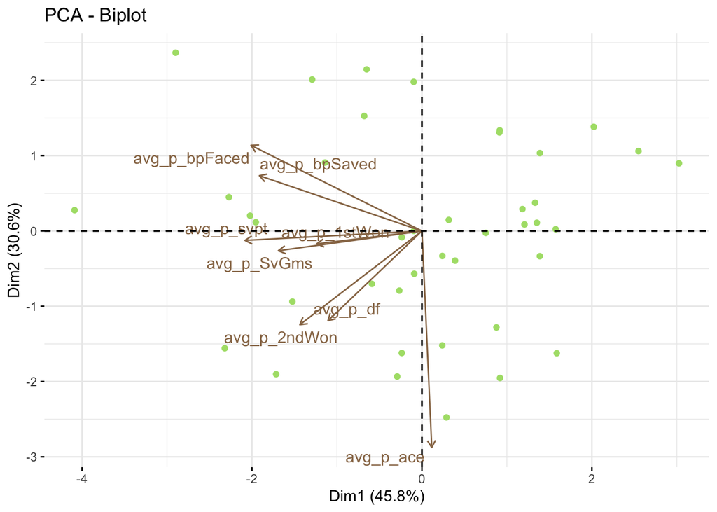

```r
# Create PCA plot
fviz_pca_biplot(pca_result_30, repel = TRUE, geom = "point", col.ind = "#acdf77", col.var = "#987654")
```

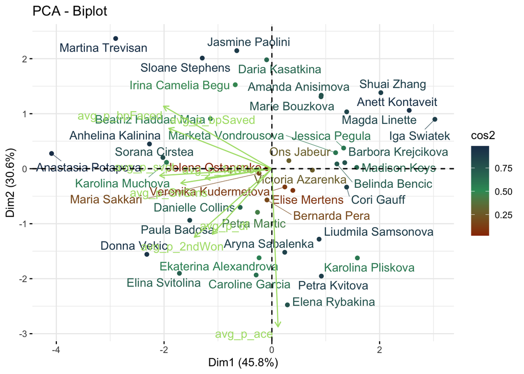

```r
# PCA plot with player names
PCA <- fviz_pca_biplot(pca_result_30, repel = TRUE,col.ind="cos2",col.var = "#acdf77", gradient.cols = c("#993300", "#339966", "#1d3b58"))

PCA
```

```r
ggsave("pca_ppt.jpeg", width = 30, height = 18, units = "cm", dpi = 300)

remove(PCA)
```

#### 2. K-medoids

Optimal k value determintaion

A. The Elbow mthod

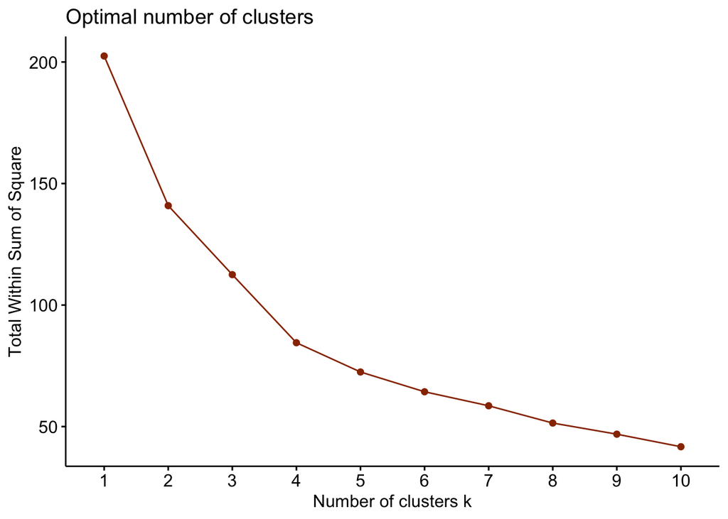

```r
library(factoextra)

# Plot clusters vs within sum of squares
fviz_nbclust(scaled_unsup_data_numeric_30, pam, method = "wss", linecol = "#993300")
```

Since the elbow method doesn’t give a good result let’s try the silhouette method.

B. The silhouette method

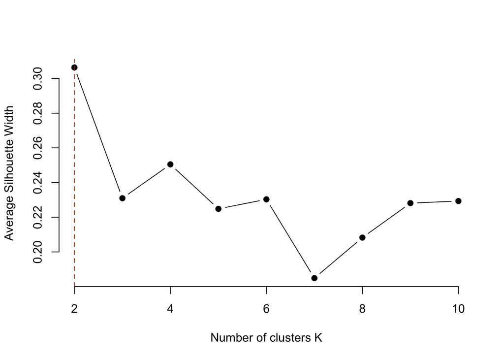

```r
library(cluster)
library(factoextra)

# Define a function to calculate average silhouette for k
avg_sil <- function(k, scaled_unsup_data_numeric_30) {
  pam.res <- pam(scaled_unsup_data_numeric_30, k = k)
  ss <- silhouette(pam.res$clustering, dist(scaled_unsup_data_numeric_30))
  mean(ss[, 3])
}

# Calculate average silhouette for k = 2 to k = 10
avg_sil_values <- sapply(2:10, function(k) avg_sil(k, scaled_unsup_data_numeric_30))

# Plot average silhouette width
plot(2:10, avg_sil_values, type = "b", pch = 19, frame = FALSE,
     xlab = "Number of clusters K", ylab = "Average Silhouette Width",)

# Add vertical line for the optimal number of clusters
abline(v = which.max(avg_sil_values) + 1, col = "#993300", lty = 2)
```

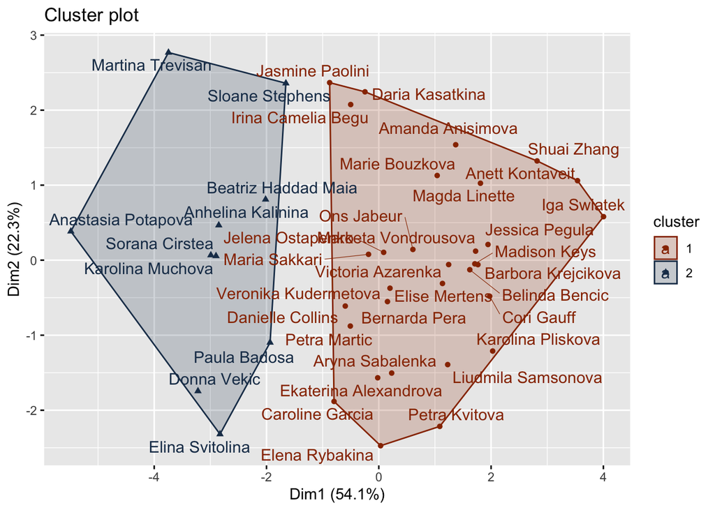

```r
set.seed(1)

rownames(scaled_unsup_data_numeric_30) <- scaled_unsup_data_filtered_30$player_name

# Perform k-medoids clustering with k = 2 clusters
kmed <- pam(scaled_unsup_data_numeric_30, k = 2)

# Plot results of the final k-medoids model
k2 <- fviz_cluster(kmed, data = scaled_unsup_data_numeric_30, palette=c("#993300", "#1d3b58"), repel = TRUE)

k2
```

```r
ggsave("k2_ppt.jpeg", width = 30, height = 18, units = "cm", dpi = 300)
```

These results reveal the presence of two distinct clusters. Further analysis indicates that cluster 1 comprises over 93% of the top 10 players. This clustering aligns logically with the nature of tennis, as top players are expected to excel across various performance metrics discussed earlier.

#### 3. Hierarchical Clustering

##### i. Complete Linkage

Complete Linkage (or Maximum Linkage): This method calculates the distance between two clusters based on the maximum distance between any pair of points in the two clusters. It tends to produce compact, spherical clusters and is less sensitive to outliers.

```r
library(dendextend)
```

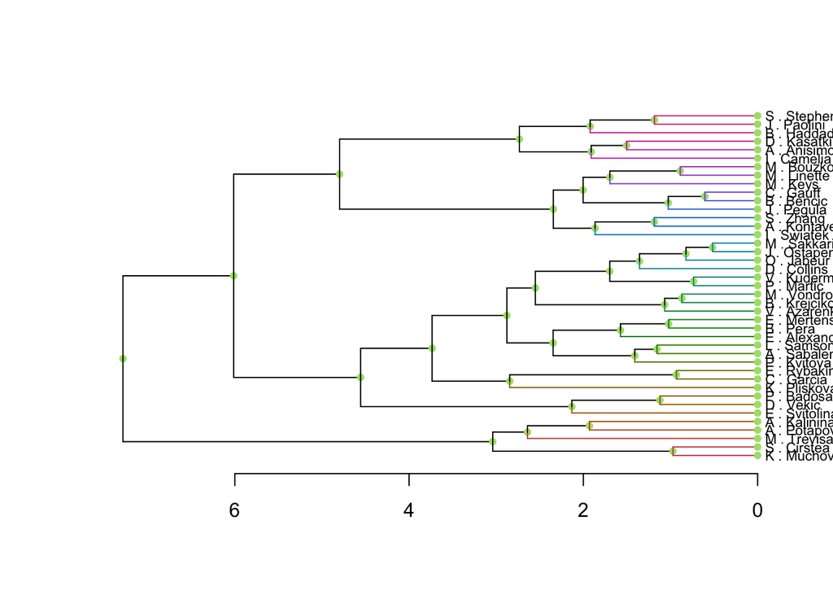

```r
# For aesthetic reasons, I will shorten the names to first name initial + last name
full_names <- scaled_unsup_data_filtered_30$player_name
abbreviate_name <- function(full_name) {
  name_parts <- strsplit(full_name, " ")[[1]]
  first_initial <- substr(name_parts[1], 1, 1)
  result <- paste(first_initial, ".", paste(name_parts[-1], collapse = " "), sep = " ")
  return(result)
}
abbreviated_names <- sapply(full_names, abbreviate_name)
rownames(scaled_unsup_data_numeric_30) <- abbreviated_names

# Perform complete hierarchical clustering
hc_c_30 <- hclust(dist(scaled_unsup_data_numeric_30), method = "complete")

# Plot the dendrogram
dend_c_30 <- as.dendrogram(hc_c_30)
dend_c_30<- color_branches(dend_c_30)
dend_c_30 %>%
  set("labels_col", "black") %>% set("labels_cex", 0.7) %>%
  set("nodes_pch", 19)  %>%
  set("nodes_cex", 0.7) %>%
  set("nodes_col", "#acdf77") %>%
  plot(horiz = TRUE)
```

##### ii. Average Linkage

Average Linkage: This method calculates the distance between two clusters based on the average distance between all pairs of points in the two clusters. It often produces more balanced clusters and is less prone to chaining than complete linkage. However, it can be sensitive to outliers and tends to create clusters of similar sizes.

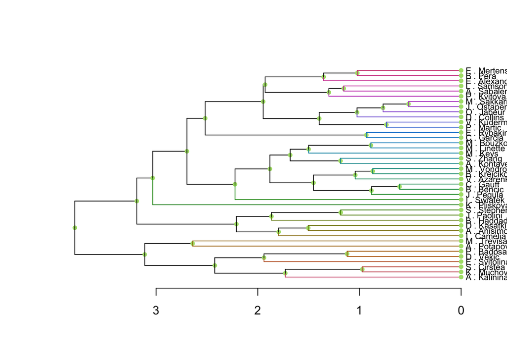

```r
library(dendextend)

# Perform average hierarchical clustering
hc_a_30 <- hclust(dist(scaled_unsup_data_numeric_30), method = "average")

# Plot the dendrogram
dend_a_30 <- as.dendrogram(hc_a_30)
dend_a_30<- color_branches(dend_a_30)
dend_a_30 %>%
  set("labels_col", "black") %>% set("labels_cex", 0.7) %>%
  set("nodes_pch", 19)  %>%
  set("nodes_cex", 0.7) %>%
  set("nodes_col", "#acdf77") %>%
  plot(horiz = TRUE)
```

##### iii. Comparison

```r
dl_c_a <- dendlist(dend_c_30, dend_a_30)
tanglegram(dl_c_a,
           common_subtrees_color_lines = FALSE, highlight_distinct_edges  = TRUE, highlight_branches_lwd=FALSE,
           margin_inner=7,
           lwd=2,
           main_left = "Complete",
           main_right = "Average"
)
```

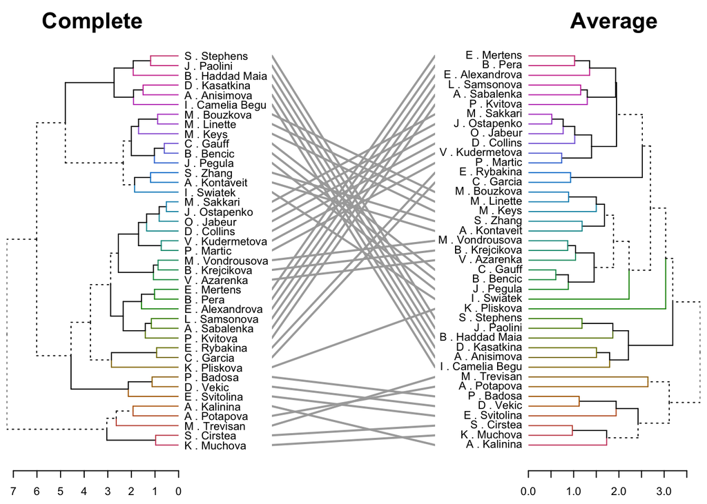

An additional noteworthy observation is the proximity between Iga Swiantek and Anett Kontaveit in the complete method, indicating similarities in their playing styles. However, in the average method, this proximity was diminished, potentially influenced by their respective rankings in the 2023 season—Swiantek held the top rank while Kontaveit ranked 17th, reflecting differences in overall performance.

Overall, the complete method highlighted distinctions in playing styles, while the average method moderated these differences, resulting in more balanced clusters that better represent the overall performance of players.

## Supervised Learning

For this part of the project, I will select a subset of the initial data and I will add a new column `set1_p_win` that is equal to 1 if p_set1 is greater than o_set1. This variable will tell us if the player has won the 1st set or not.

```r
sup_data <- data[, c("win", "grand_slam", "final_rounds", "surface", "player_hand", "player_ht", "player_age",
                     "opponent_hand", "opponent_ht", "opponent_age", "p_set1", "o_set1",
                     "minutes", "player_rank", "opponent_rank")]

sup_data$set1_p_win <- ifelse(sup_data$p_set1 > sup_data$o_set1, 1, 0)

sup_data <- sup_data[, -c(11, 12)]
```

Encoding the resting categorical variables:

```r
sup_data$player_hand_R <- ifelse(sup_data$player_hand == "R", 1, 0)
sup_data$opponent_hand_R <- ifelse(sup_data$opponent_hand == "R", 1, 0)

sup_data$surface_grass <- ifelse(sup_data$surface == "Grass", 1, 0)
sup_data$surface_clay <- ifelse(sup_data$surface == "Clay", 1, 0)

sup_data <- sup_data[, -c(4, 5,8)]
```

Scaling

```r
# Select only numeric columns except for "win", "GS", and "final_rounds"
sup_numeric_data <- sup_data[, sapply(sup_data, is.numeric) & !names(sup_data) %in% c("win", "final_rounds","grand_slam","set1_p_win","player_hand_R","opponent_hand_R","surface_grass","surface_clay")]

# Scale the numeric columns
scaled_sup_numeric_data <- scale(sup_numeric_data)

# Combine the scaled numeric columns with the non-numeric columns
scaled_sup_data <- cbind(sup_data[, !sapply(sup_data, is.numeric) | names(sup_data) %in% c("win", "final_rounds","grand_slam","set1_p_win","player_hand_R","opponent_hand_R","surface_grass","surface_clay")], scaled_sup_numeric_data)

remove(scaled_sup_numeric_data, sup_numeric_data)
```

Correlation

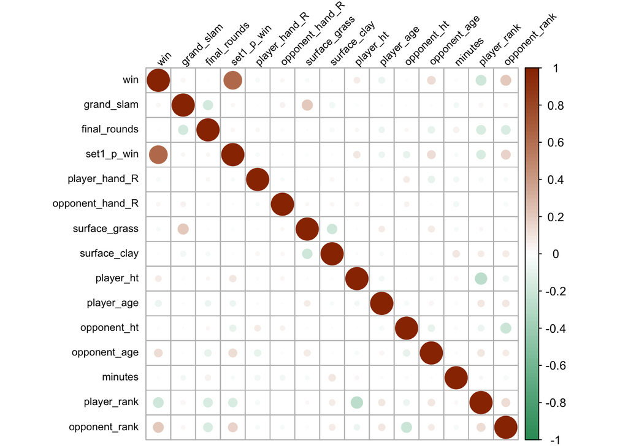

```r
library(corrplot)
M <- cor(scaled_sup_data)

# Plotting
corrplot(M,
         col = colorRampPalette(c("#339966", "white", "#993300"))(100),
         tl.col = "black",
         tl.srt = 45,
         tl.pos = "lt",
         tl.cex = 0.7)
```

### 1. Logistic Regression

Splitting data into Training and Test datasets.

```r
library(caret)
set.seed(123)

# Split data into training (80%) and test (20%) sets
train_indices <- createDataPartition(sup_data$win, p = 0.8, list = FALSE)
train_data <- sup_data[train_indices, ]
test_data <- sup_data[-train_indices, ]


# Split data into training (80%) and test (20%) sets
scaled_train_indices <- createDataPartition(scaled_sup_data$win, p = 0.8, list = FALSE)
scaled_train_data <- scaled_sup_data[scaled_train_indices, ]
scaled_test_data <- scaled_sup_data[-scaled_train_indices, ]
```

```r
lr_f_model <- glm(win ~.,family=binomial(link='logit'),data=scaled_train_data)

summary(lr_f_model)
```

```
##
## Call:
## glm(formula = win ~ ., family = binomial(link = "logit"), data = scaled_train_data)
##
## Coefficients:
##                  Estimate Std. Error z value Pr(>|z|)
## (Intercept)     -1.457728   0.415183  -3.511 0.000446 ***
## grand_slam       0.201468   0.236430   0.852 0.394144
## final_rounds     0.022492   0.227927   0.099 0.921391
## set1_p_win       2.988244   0.190137  15.716  < 2e-16 ***
## player_hand_R   -0.080270   0.305099  -0.263 0.792477
## opponent_hand_R  0.100903   0.308016   0.328 0.743221
## surface_grass   -0.425802   0.310442  -1.372 0.170189
## surface_clay    -0.159534   0.238644  -0.669 0.503813
## player_ht       -0.004203   0.093706  -0.045 0.964224
## player_age      -0.123226   0.094676  -1.302 0.193066
## opponent_ht      0.185792   0.096127   1.933 0.053264 .
## opponent_age     0.138199   0.098005   1.410 0.158504
## minutes          0.069369   0.094424   0.735 0.462549
## player_rank     -0.453309   0.102160  -4.437 9.11e-06 ***
## opponent_rank    0.447368   0.100410   4.455 8.37e-06 ***
## ---
## Signif. codes:  0 '***' 0.001 '**' 0.01 '*' 0.05 '.' 0.1 ' ' 1
##
## (Dispersion parameter for binomial family taken to be 1)
##
##     Null deviance: 1176.34  on 848  degrees of freedom
## Residual deviance:  747.98  on 834  degrees of freedom
## AIC: 777.98
##
## Number of Fisher Scoring iterations: 4
```

let’s check for multicollinearity.

```r
car::vif(lr_f_model)
```

```
##      grand_slam    final_rounds      set1_p_win   player_hand_R opponent_hand_R
##        1.084810        1.099895        1.055464        1.027015        1.016912
##   surface_grass    surface_clay       player_ht      player_age     opponent_ht
##        1.088553        1.061866        1.082043        1.037932        1.102887
##    opponent_age         minutes     player_rank   opponent_rank
##        1.064010        1.019928        1.164337        1.140344
```

As a rule of thumb, a VIF value that exceeds 5 or 10 indicates a problematic amount of collinearity. In our example, there is no collinearity: all variables have a value of VIF well below 5.

```r
lr_r_model <- step(lr_f_model, direction = "backward")
```

```
## Start:  AIC=777.98
## win ~ grand_slam + final_rounds + set1_p_win + player_hand_R +
##     opponent_hand_R + surface_grass + surface_clay + player_ht +
##     player_age + opponent_ht + opponent_age + minutes + player_rank +
##     opponent_rank
##
##                   Df Deviance     AIC
## - player_ht        1   747.98  775.98
## - final_rounds     1   747.99  775.99
## - player_hand_R    1   748.05  776.05
## - opponent_hand_R  1   748.09  776.09
## - surface_clay     1   748.43  776.43
## - minutes          1   748.52  776.52
## - grand_slam       1   748.71  776.71
## - player_age       1   749.68  777.68
## - surface_grass    1   749.87  777.87
## - opponent_age     1   749.98  777.98
## <none>                 747.98  777.98
## - opponent_ht      1   751.75  779.75
## - player_rank      1   768.32  796.32
## - opponent_rank    1   768.46  796.46
## - set1_p_win       1  1066.32 1094.32
##
## Step:  AIC=775.98
## win ~ grand_slam + final_rounds + set1_p_win + player_hand_R +
##     opponent_hand_R + surface_grass + surface_clay + player_age +
##     opponent_ht + opponent_age + minutes + player_rank + opponent_rank
##
##                   Df Deviance     AIC
## - final_rounds     1   747.99  773.99
## - player_hand_R    1   748.05  774.05
## - opponent_hand_R  1   748.09  774.09
## - surface_clay     1   748.43  774.43
## - minutes          1   748.52  774.52
## - grand_slam       1   748.71  774.71
## - player_age       1   749.68  775.68
## - surface_grass    1   749.87  775.87
## - opponent_age     1   749.98  775.98
## <none>                 747.98  775.98
## - opponent_ht      1   751.76  777.76
```

[output cut: 124 more lines]

```
## <none>               752.95  764.95
## - opponent_ht    1   756.49  766.49
## - opponent_rank  1   773.32  783.32
## - player_rank    1   773.60  783.60
## - set1_p_win     1  1084.68 1094.68
##
## Step:  AIC=764.71
## win ~ set1_p_win + opponent_ht + player_rank + opponent_rank
##
##                 Df Deviance     AIC
## <none>               754.71  764.71
## - opponent_ht    1   758.30  766.30
## - opponent_rank  1   774.23  782.23
## - player_rank    1   776.04  784.04
## - set1_p_win     1  1092.04 1100.04
```

```r
summary(lr_r_model)
```

```
##
## Call:
## glm(formula = win ~ set1_p_win + opponent_ht + player_rank +
##     opponent_rank, family = binomial(link = "logit"), data = scaled_train_data)
##
## Coefficients:
##               Estimate Std. Error z value Pr(>|z|)
## (Intercept)   -1.48370    0.13338 -11.124  < 2e-16 ***
## set1_p_win     3.02506    0.18787  16.102  < 2e-16 ***
## opponent_ht    0.17902    0.09488   1.887   0.0592 .
## player_rank   -0.44054    0.09687  -4.548 5.42e-06 ***
## opponent_rank  0.42658    0.09788   4.358 1.31e-05 ***
## ---
## Signif. codes:  0 '***' 0.001 '**' 0.01 '*' 0.05 '.' 0.1 ' ' 1
##
## (Dispersion parameter for binomial family taken to be 1)
##
##     Null deviance: 1176.34  on 848  degrees of freedom
## Residual deviance:  754.71  on 844  degrees of freedom
## AIC: 764.71
##
## Number of Fisher Scoring iterations: 4
```

From the output above, we can see that: - The players who win the 1st set, compared to those who lose their 1st set, increase their win changes (log odds) by 3.02506, keeping everything else constant. To understand more the coefficients, let’s exponentiate them and interpret them as odds-ratios.

```r
exp(coef(lr_r_model))
```

```
##   (Intercept)    set1_p_win   opponent_ht   player_rank opponent_rank
##     0.2267977    20.5952856     1.1960389     0.6436892     1.5320034
```

#### Confusion Matrix

```r
library(caret)

# Predict probabilities for the test data
lr_r_predicted_prob <- predict(lr_r_model, newdata = scaled_test_data, type = "response")

# Convert probabilities to binary predictions (0 or 1) using a threshold of 0.5
lr_r_predicted_classes <- ifelse(lr_r_predicted_prob > 0.5, 1, 0)

# Create confusion matrix
lr_confusion_matrix <- confusionMatrix(factor(lr_r_predicted_classes), factor(scaled_test_data$win))

# Display confusion matrix
lr_confusion_matrix
```

```
## Confusion Matrix and Statistics
##
##           Reference
## Prediction  0  1
##          0 96 21
##          1 24 71
##
##                Accuracy : 0.7877
##                  95% CI : (0.7265, 0.8408)
##     No Information Rate : 0.566
##     P-Value [Acc > NIR] : 1.033e-11
##
##                   Kappa : 0.5696
##
##  Mcnemar's Test P-Value : 0.7656
##
##             Sensitivity : 0.8000
##             Specificity : 0.7717
##          Pos Pred Value : 0.8205
##          Neg Pred Value : 0.7474
##              Prevalence : 0.5660
##          Detection Rate : 0.4528
##    Detection Prevalence : 0.5519
##       Balanced Accuracy : 0.7859
##
##        'Positive' Class : 0
##
```

#### ROC Curve

```r
library(pROC)
```

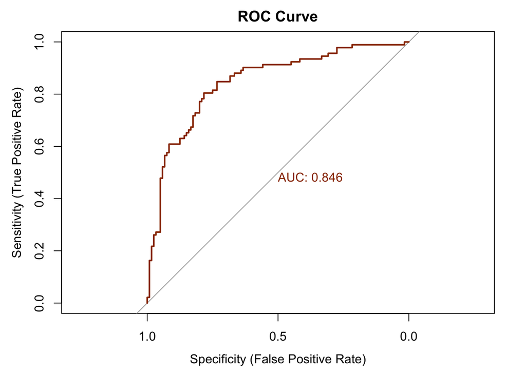

```r
# Create an ROC curve object
lr_r_roc <- roc(scaled_test_data$win, lr_r_predicted_prob)
# Plot the ROC curve
plot(lr_r_roc, col = "#993300", lwd = 2,
     main = "ROC Curve",
     xlab = "Specificity (False Positive Rate)",
     ylab = "Sensitivity (True Positive Rate)",
     plot = TRUE, print.auc = TRUE)
```

The AUC is calculated as 0.846. This means that there is an 84.6% chance that the model will be able to distinguish between positive and negative outcomes. In other words, the model has a good discriminatory ability, with a higher probability of correctly ranking a randomly chosen positive instance higher than a randomly chosen negative instance.

```r
train_data_f <- train_data
# Subset train_data to include only the specified columns
train_data <- train_data[, c("win", "set1_p_win", "opponent_age", "player_rank", "opponent_rank")]
scaled_train_data <- scaled_train_data[, c("win", "set1_p_win", "opponent_age", "player_rank", "opponent_rank")]

test_data_f <- test_data
# Subset test_data to include only the specified columns
test_data <- test_data[, c("win", "set1_p_win", "opponent_age", "player_rank", "opponent_rank")]
scaled_test_data <- scaled_test_data[, c("win", "set1_p_win", "opponent_age", "player_rank", "opponent_rank")]
```

### 2. Decion Tree

```r
# Load the rpart package
library(rpart)
set.seed(123)


# Convert the "win" column in train_data to a factor
train_data$win <- factor(train_data$win)

# Convert the "win" column in test_data to a factor
test_data$win <- factor(test_data$win)

# Define the decision tree model
dt_model <- rpart(win ~ ., data = train_data)

# Make predictions on the test data
dt_predicted_classes <- predict(dt_model, test_data, type = "class")

# Evaluate performance
dt_confusion_matrix <- table(dt_predicted_classes, test_data$win)
dt_accuracy <- sum(diag(dt_confusion_matrix)) / sum(dt_confusion_matrix)

# Print confusion matrix and accuracy
print(dt_confusion_matrix)
```

```
##
## dt_predicted_classes  0  1
##                    0 80 20
##                    1 24 88
```

```r
print(dt_accuracy)
```

```
## [1] 0.7924528
```

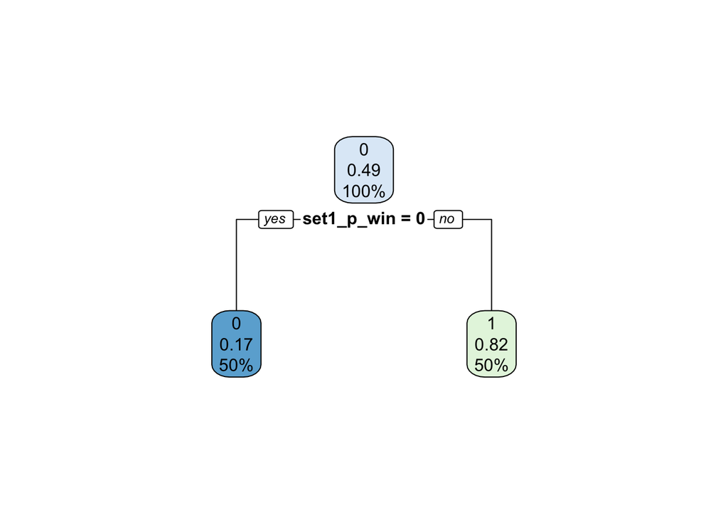

```r
# Load the rpart.plot package
library(rpart.plot)

# Plot the decision tree
rpart.plot(dt_model)
```

```r
dt_model
```

```
## n= 849
##
## node), split, n, loss, yval, (yprob)
##       * denotes terminal node
##
## 1) root 849 420 0 (0.5053004 0.4946996)
##   2) set1_p_win< 0.5 426  74 0 (0.8262911 0.1737089) *
##   3) set1_p_win>=0.5 423  77 1 (0.1820331 0.8179669) *
```

We can see in this model above that the only feature highlighted is the one related to winning the 1st set. For the sake of experimentation, I will add the other variables that were eliminated by the the backward selection in the logistic regression model and let the decision tree model do the feature selection.

```r
# Load the rpart package
library(rpart)


set.seed(123)

# Convert the "win" column in train_data to a factor
train_data_f$win <- factor(train_data_f$win)

# Convert the "win" column in test_data to a factor
test_data_f$win <- factor(test_data_f$win)

# Define the decision tree model
dt_f_model <- rpart(win ~ ., data = train_data_f)

# Make predictions on the test data
dt_f_predicted_classes <- predict(dt_f_model, test_data_f, type = "class")

# Evaluate performance
dt_f_confusion_matrix <- table(dt_f_predicted_classes, test_data_f$win)
dt_f_accuracy <- sum(diag(dt_f_confusion_matrix)) / sum(dt_f_confusion_matrix)

# Print confusion matrix and accuracy
print(dt_f_confusion_matrix)
```

```
##
## dt_f_predicted_classes  0  1
##                      0 86 29
##                      1 18 79
```

```r
print(dt_f_accuracy)
```

```
## [1] 0.7783019
```

```r
dt_f_model
```

```
## n= 849
##
## node), split, n, loss, yval, (yprob)
##       * denotes terminal node
##
##  1) root 849 420 0 (0.50530035 0.49469965)
##    2) set1_p_win< 0.5 426  74 0 (0.82629108 0.17370892) *
##    3) set1_p_win>=0.5 423  77 1 (0.18203310 0.81796690)
##      6) minutes>=115.5 147  65 1 (0.44217687 0.55782313)
##       12) player_rank>=53 36  13 0 (0.63888889 0.36111111) *
##       13) player_rank< 53 111  42 1 (0.37837838 0.62162162) *
##      7) minutes< 115.5 276  12 1 (0.04347826 0.95652174) *
```

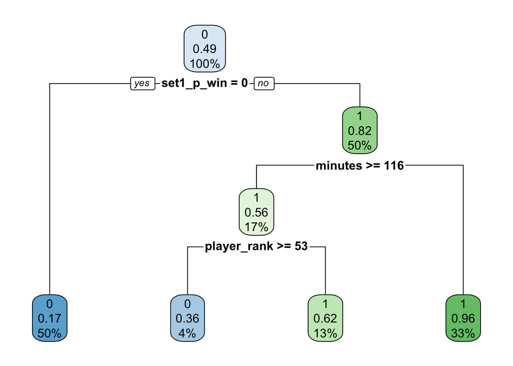

```r
rpart.plot(dt_f_model)
```

### 3. Random Forest

```r
# Load the randomForest package
library(randomForest)
set.seed(22)

# Define the Random Forest model
rf_model <- randomForest(win ~ .,
                         data = train_data_f,
                         ntree = 500,  # Number of trees in the forest
                         mtry = 2)     # Number of variables randomly sampled as candidates at each split

# Make predictions on the test data
rf_predicted_classes <- predict(rf_model, test_data_f)

# Evaluate performance
rf_confusion_matrix <- table(rf_predicted_classes, test_data_f$win)
rf_accuracy <- sum(diag(rf_confusion_matrix)) / sum(rf_confusion_matrix)

# Print confusion matrix and accuracy
print(rf_confusion_matrix)
```

```
##
## rf_predicted_classes  0  1
##                    0 81 22
##                    1 23 86
```

```r
print(rf_accuracy)
```

```
## [1] 0.7877358
```

## Challenges & Limitations

- Time Discounting: naive historical averaging overlooks the fact that not all of a player’s past matches are equally relevant in predicting their performance. We can address this by taking weighted averages, and giving a higher weight to past matches which we think are more relevant for predicting the upcoming match.
- Others features: Injuries, Physical form, etc.